```python
import pandas as pd
import matplotlib.pyplot as plt
from scipy import stats
import numpy as np
```

# Replicability Study

## Dataframes for Different Years and Leagues

### Ligue 1

```python
years = range(2014, 2024)
dataframes = {}
```

```python
base_path = './match_database/ligue1/'
```

```python
for year in years:
    file_path = f'{base_path}{year}.csv'  # Dynamically create file paths
    dataframes[f'df{year}'] = pd.read_csv(file_path)
```

```python
df_ligue1_2014 = dataframes['df2014']
df_ligue1_2015 = dataframes['df2015']
df_ligue1_2016 = dataframes['df2016']
df_ligue1_2017 = dataframes['df2017']
df_ligue1_2018 = dataframes['df2018']
df_ligue1_2019 = dataframes['df2019']
df_ligue1_2020 = dataframes['df2020']
df_ligue1_2021 = dataframes['df2021']
df_ligue1_2022 = dataframes['df2022']
df_ligue1_2023 = dataframes['df2023']
```

### La Liga

```python
years = range(2014, 2024)
dataframes = {}
```

```python
base_path = './match_database/la_liga/'
```

```python
for year in years:
    file_path = f'{base_path}{year}.csv'  # Dynamically create file paths
    dataframes[f'df{year}'] = pd.read_csv(file_path)
```

```python
df_laliga_2014 = dataframes['df2014']
df_laliga_2015 = dataframes['df2015']
df_laliga_2016 = dataframes['df2016']
df_laliga_2017 = dataframes['df2017']
df_laliga_2018 = dataframes['df2018']
df_laliga_2019 = dataframes['df2019']
df_laliga_2020 = dataframes['df2020']
df_laliga_2021 = dataframes['df2021']
df_laliga_2022 = dataframes['df2022']
df_laliga_2023 = dataframes['df2023']
```

### Bundesliga

```python
years = range(2014, 2024)
dataframes = {}
```

```python
base_path = './match_database/bundesliga/'
```

```python
for year in years:
    file_path = f'{base_path}{year}.csv'  # Dynamically create file paths
    dataframes[f'df{year}'] = pd.read_csv(file_path)
```

```python
df_bundesliga_2014 = dataframes['df2014']
df_bundesliga_2015 = dataframes['df2015']
df_bundesliga_2016 = dataframes['df2016']
df_bundesliga_2017 = dataframes['df2017']
df_bundesliga_2018 = dataframes['df2018']
df_bundesliga_2019 = dataframes['df2019']
df_bundesliga_2020 = dataframes['df2020']
df_bundesliga_2021 = dataframes['df2021']
df_bundesliga_2022 = dataframes['df2022']
df_bundesliga_2023 = dataframes['df2023']
```

### EPL

```python
years = range(2014, 2024)
dataframes = {}
```

```python
base_path = './match_database/epl/'
```

```python
for year in years:
    file_path = f'{base_path}{year}.csv'  # Dynamically create file paths
    dataframes[f'df{year}'] = pd.read_csv(file_path)
```

```python
df_epl_2014 = dataframes['df2014']
df_epl_2015 = dataframes['df2015']
df_epl_2016 = dataframes['df2016']
df_epl_2017 = dataframes['df2017']
df_epl_2018 = dataframes['df2018']
df_epl_2019 = dataframes['df2019']
df_epl_2020 = dataframes['df2020']
df_epl_2021 = dataframes['df2021']
df_epl_2022 = dataframes['df2022']
df_epl_2023 = dataframes['df2023']
```

### Serie A

```python
years = range(2014, 2024)
dataframes = {}
```

```python
base_path = './match_database/serieA/'
```

```python
for year in years:
    file_path = f'{base_path}{year}.csv'  # Dynamically create file paths
    dataframes[f'df{year}'] = pd.read_csv(file_path)
```

```python
df_seriea_2014 = dataframes['df2014']
df_seriea_2015 = dataframes['df2015']
df_seriea_2016 = dataframes['df2016']
df_seriea_2017 = dataframes['df2017']
df_seriea_2018 = dataframes['df2018']
df_seriea_2019 = dataframes['df2019']
df_seriea_2020 = dataframes['df2020']
df_seriea_2021 = dataframes['df2021']
df_seriea_2022 = dataframes['df2022']
df_seriea_2023 = dataframes['df2023']
```

### RFPL

```python
years = range(2014, 2024)
dataframes = {}
```

```python
base_path = './match_database/rfpl/'
```

```python
for year in years:
    file_path = f'{base_path}{year}.csv'  # Dynamically create file paths
    dataframes[f'df{year}'] = pd.read_csv(file_path)
```

```python
df_rfpl_2014 = dataframes['df2014']
df_rfpl_2015 = dataframes['df2015']
df_rfpl_2016 = dataframes['df2016']
df_rfpl_2017 = dataframes['df2017']
df_rfpl_2018 = dataframes['df2018']
df_rfpl_2019 = dataframes['df2019']
df_rfpl_2020 = dataframes['df2020']
df_rfpl_2021 = dataframes['df2021']
df_rfpl_2022 = dataframes['df2022']
df_rfpl_2023 = dataframes['df2023']
```

## Changing Statistical Tests for Assessing Differences Between Home and Away Matches

### Using Paired t-Test instead of Wilcoxon

```python
results_stat = pd.DataFrame()
```

### Ligue 1

```python
dataframes = {
    2014: df_ligue1_2014,
    2015: df_ligue1_2015,
    2016: df_ligue1_2016,
    2017: df_ligue1_2017,
    2018: df_ligue1_2018,
    2019: df_ligue1_2019,
    2020: df_ligue1_2020,
}
```

```python
for season, df in dataframes.items():
    # Filter data for home and away games
    home_pts = df[df['h_a'] == 'h']['pts']
    away_pts = df[df['h_a'] == 'a']['pts']
    home_xpts = df[df['h_a'] == 'h']['xpts']
    away_xpts = df[df['h_a'] == 'a']['xpts']
    home_xg = df[df['h_a'] == 'h']['xG']
    away_xg = df[df['h_a'] == 'a']['xG']

    # Perform Paired t-Test
    ttest_result = stats.ttest_rel(home_pts, away_pts)
    ttest_xpts = stats.ttest_rel(home_xpts, away_xpts)
    ttest_xg = stats.ttest_rel(home_xg, away_xg)

    # Store results in a dictionary
    result = {
        "league": "Ligue_1",
        "season": season,
        "ttest_result": ttest_result.statistic,
        "ttest_result-pvalue": ttest_result.pvalue,
        "ttest-xPoints": ttest_xpts.statistic,
        "ttest-xPoints-pvalue": ttest_xpts.pvalue,
        "ttest-xG": ttest_xg.statistic,
        "ttest-xG-pvalue": ttest_xg.pvalue,
    }

    # Append the result to the results list
    results_stat = pd.concat([results_stat, pd.DataFrame([result])], ignore_index=True)
```

```python
results_stat
```

|  | league | season | ttest_result | ttest_result-pvalue | ttest-xPoints | ttest-xPoints-pvalue | ttest-xG | ttest-xG-pvalue |
| --- | --- | --- | --- | --- | --- | --- | --- | --- |
| 0 | Ligue_1 | 2014 | 5.894396 | 8.319528e-09 | 8.900834 | 2.322085e-17 | 6.346558 | 6.291324e-10 |
| 1 | Ligue_1 | 2015 | 4.439287 | 1.185318e-05 | 10.232121 | 7.348729e-22 | 7.471841 | 5.514790e-13 |
| 2 | Ligue_1 | 2016 | 7.485472 | 5.038320e-13 | 9.969743 | 6.049650e-21 | 7.042312 | 8.947314e-12 |
| 3 | Ligue_1 | 2017 | 5.681467 | 2.665015e-08 | 9.077650 | 6.166917e-18 | 6.926051 | 1.863199e-11 |
| 4 | Ligue_1 | 2018 | 5.301624 | 1.953816e-07 | 8.264811 | 2.380272e-15 | 7.056480 | 8.177240e-12 |
| 5 | Ligue_1 | 2019 | 6.167353 | 2.440138e-09 | 6.982315 | 2.137746e-11 | 5.642696 | 4.121886e-08 |
| 6 | Ligue_1 | 2020 | -0.086525 | 9.310944e-01 | 2.790627 | 5.526608e-03 | 2.735234 | 6.526492e-03 |

### La Liga

```python
dataframes = {
    2014: df_laliga_2014,
    2015: df_laliga_2015,
    2016: df_laliga_2016,
    2017: df_laliga_2017,
    2018: df_laliga_2018,
    2019: df_laliga_2019,
    2020: df_laliga_2020,
}
```

```python
for season, df in dataframes.items():
    # Filter data for home and away games
    home_pts = df[df['h_a'] == 'h']['pts']
    away_pts = df[df['h_a'] == 'a']['pts']
    home_xpts = df[df['h_a'] == 'h']['xpts']
    away_xpts = df[df['h_a'] == 'a']['xpts']
    home_xg = df[df['h_a'] == 'h']['xG']
    away_xg = df[df['h_a'] == 'a']['xG']

     # Perform Paired t-Test
    ttest_result = stats.ttest_rel(home_pts, away_pts)
    ttest_xpts = stats.ttest_rel(home_xpts, away_xpts)
    ttest_xg = stats.ttest_rel(home_xg, away_xg)

    # Store results in a dictionary
    result = {
        "league": "La_liga",
        "season": season,
        "ttest_result": ttest_result.statistic,
        "ttest_result-pvalue": ttest_result.pvalue,
        "ttest-xPoints": ttest_xpts.statistic,
        "ttest-xPoints-pvalue": ttest_xpts.pvalue,
        "ttest-xG": ttest_xg.statistic,
        "ttest-xG-pvalue": ttest_xg.pvalue,
    }

    # Append the result to the results list
    results_stat = pd.concat([results_stat, pd.DataFrame([result])], ignore_index=True)
```

### EPL

```python
dataframes = {
    2014: df_epl_2014,
    2015: df_epl_2015,
    2016: df_epl_2016,
    2017: df_epl_2017,
    2018: df_epl_2018,
    2019: df_epl_2019,
    2020: df_epl_2020,
}
```

```python
for season, df in dataframes.items():
    # Filter data for home and away games
    home_pts = df[df['h_a'] == 'h']['pts']
    away_pts = df[df['h_a'] == 'a']['pts']
    home_xpts = df[df['h_a'] == 'h']['xpts']
    away_xpts = df[df['h_a'] == 'a']['xpts']
    home_xg = df[df['h_a'] == 'h']['xG']
    away_xg = df[df['h_a'] == 'a']['xG']

    # Perform Paired t-Test
    ttest_result = stats.ttest_rel(home_pts, away_pts)
    ttest_xpts = stats.ttest_rel(home_xpts, away_xpts)
    ttest_xg = stats.ttest_rel(home_xg, away_xg)

    # Store results in a dictionary
    result = {
        "league": "EPL",
        "season": season,
        "ttest_result": ttest_result.statistic,
        "ttest_result-pvalue": ttest_result.pvalue,
        "ttest-xPoints": ttest_xpts.statistic,
        "ttest-xPoints-pvalue": ttest_xpts.pvalue,
        "ttest-xG": ttest_xg.statistic,
        "ttest-xG-pvalue": ttest_xg.pvalue,
    }

    # Append the result to the results list
    results_stat = pd.concat([results_stat, pd.DataFrame([result])], ignore_index=True)
```

### Bundesliga

```python
dataframes = {
    2014: df_bundesliga_2014,
    2015: df_bundesliga_2015,
    2016: df_bundesliga_2016,
    2017: df_bundesliga_2017,
    2018: df_bundesliga_2018,
    2019: df_bundesliga_2019,
    2020: df_bundesliga_2020,
}
```

```python
for season, df in dataframes.items():
    # Filter data for home and away games
    home_pts = df[df['h_a'] == 'h']['pts']
    away_pts = df[df['h_a'] == 'a']['pts']
    home_xpts = df[df['h_a'] == 'h']['xpts']
    away_xpts = df[df['h_a'] == 'a']['xpts']
    home_xg = df[df['h_a'] == 'h']['xG']
    away_xg = df[df['h_a'] == 'a']['xG']

     # Perform Paired t-Test
    ttest_result = stats.ttest_rel(home_pts, away_pts)
    ttest_xpts = stats.ttest_rel(home_xpts, away_xpts)
    ttest_xg = stats.ttest_rel(home_xg, away_xg)

    # Store results in a dictionary
    result = {
        "league": "Bundesliga",
        "season": season,
        "ttest_result": ttest_result.statistic,
        "ttest_result-pvalue": ttest_result.pvalue,
        "ttest-xPoints": ttest_xpts.statistic,
        "ttest-xPoints-pvalue": ttest_xpts.pvalue,
        "ttest-xG": ttest_xg.statistic,
        "ttest-xG-pvalue": ttest_xg.pvalue,
    }

    # Append the result to the results list
    results_stat = pd.concat([results_stat, pd.DataFrame([result])], ignore_index=True)
```

### Serie A

```python
dataframes = {
    2014: df_seriea_2014,
    2015: df_seriea_2015,
    2016: df_seriea_2016,
    2017: df_seriea_2017,
    2018: df_seriea_2018,
    2019: df_seriea_2019,
    2020: df_seriea_2020,
}
```

```python
for season, df in dataframes.items():
    # Filter data for home and away games
    home_pts = df[df['h_a'] == 'h']['pts']
    away_pts = df[df['h_a'] == 'a']['pts']
    home_xpts = df[df['h_a'] == 'h']['xpts']
    away_xpts = df[df['h_a'] == 'a']['xpts']
    home_xg = df[df['h_a'] == 'h']['xG']
    away_xg = df[df['h_a'] == 'a']['xG']

     # Perform Paired t-Test
    ttest_result = stats.ttest_rel(home_pts, away_pts)
    ttest_xpts = stats.ttest_rel(home_xpts, away_xpts)
    ttest_xg = stats.ttest_rel(home_xg, away_xg)

    # Store results in a dictionary
    result = {
        "league": "Serie_A",
        "season": season,
        "ttest_result": ttest_result.statistic,
        "ttest_result-pvalue": ttest_result.pvalue,
        "ttest-xPoints": ttest_xpts.statistic,
        "ttest-xPoints-pvalue": ttest_xpts.pvalue,
        "ttest-xG": ttest_xg.statistic,
        "ttest-xG-pvalue": ttest_xg.pvalue,
    }

    # Append the result to the results list
    results_stat = pd.concat([results_stat, pd.DataFrame([result])], ignore_index=True)
```

### RFPL

```python
dataframes = {
    2014: df_rfpl_2014,
    2015: df_rfpl_2015,
    2016: df_rfpl_2016,
    2017: df_rfpl_2017,
    2018: df_rfpl_2018,
    2019: df_rfpl_2019,
    2020: df_rfpl_2020,
}
```

```python
for season, df in dataframes.items():
    # Filter data for home and away games
    home_pts = df[df['h_a'] == 'h']['pts']
    away_pts = df[df['h_a'] == 'a']['pts']
    home_xpts = df[df['h_a'] == 'h']['xpts']
    away_xpts = df[df['h_a'] == 'a']['xpts']
    home_xg = df[df['h_a'] == 'h']['xG']
    away_xg = df[df['h_a'] == 'a']['xG']

     # Perform Paired t-Test
    ttest_result = stats.ttest_rel(home_pts, away_pts)
    ttest_xpts = stats.ttest_rel(home_xpts, away_xpts)
    ttest_xg = stats.ttest_rel(home_xg, away_xg)

    # Store results in a dictionary
    result = {
        "league": "RFPL",
        "season": season,
        "ttest_result": ttest_result.statistic,
        "ttest_result-pvalue": ttest_result.pvalue,
        "ttest-xPoints": ttest_xpts.statistic,
        "ttest-xPoints-pvalue": ttest_xpts.pvalue,
        "ttest-xG": ttest_xg.statistic,
        "ttest-xG-pvalue": ttest_xg.pvalue,
    }

    # Append the result to the results list
    results_stat = pd.concat([results_stat, pd.DataFrame([result])], ignore_index=True)
```

```python
def highlight_pvalues(val):
    try:
        if pd.notna(val) and float(val) > 0.05:
            return 'color: red;'  # Highlight significant p-values in red
    except ValueError:
        pass
    return ''
```

```python
styled_results_stat = results_stat.style.applymap(highlight_pvalues, subset=[
    'ttest_result-pvalue', 'ttest-xPoints-pvalue', 'ttest-xG-pvalue'
])
```

```python
styled_results_stat
```

|  | league | season | ttest_result | ttest_result-pvalue | ttest-xPoints | ttest-xPoints-pvalue | ttest-xG | ttest-xG-pvalue |
| --- | --- | --- | --- | --- | --- | --- | --- | --- |
| 0 | Ligue_1 | 2014 | 5.894396 | 0.000000 | 8.900834 | 0.000000 | 6.346558 | 0.000000 |
| 1 | Ligue_1 | 2015 | 4.439287 | 0.000012 | 10.232121 | 0.000000 | 7.471841 | 0.000000 |
| 2 | Ligue_1 | 2016 | 7.485472 | 0.000000 | 9.969743 | 0.000000 | 7.042312 | 0.000000 |
| 3 | Ligue_1 | 2017 | 5.681467 | 0.000000 | 9.077650 | 0.000000 | 6.926051 | 0.000000 |
| 4 | Ligue_1 | 2018 | 5.301624 | 0.000000 | 8.264811 | 0.000000 | 7.056480 | 0.000000 |
| 5 | Ligue_1 | 2019 | 6.167353 | 0.000000 | 6.982315 | 0.000000 | 5.642696 | 0.000000 |
| 6 | Ligue_1 | 2020 | -0.086525 | 0.931094 | 2.790627 | 0.005527 | 2.735234 | 0.006526 |
| 7 | La_liga | 2014 | 4.826327 | 0.000002 | 10.144456 | 0.000000 | 7.462015 | 0.000000 |
| 8 | La_liga | 2015 | 6.752000 | 0.000000 | 8.710303 | 0.000000 | 7.275050 | 0.000000 |
| 9 | La_liga | 2016 | 6.146814 | 0.000000 | 10.307581 | 0.000000 | 7.354092 | 0.000000 |
| 10 | La_liga | 2017 | 5.491981 | 0.000000 | 11.757590 | 0.000000 | 8.672836 | 0.000000 |
| 11 | La_liga | 2018 | 6.009143 | 0.000000 | 11.014827 | 0.000000 | 7.108462 | 0.000000 |
| 12 | La_liga | 2019 | 6.568223 | 0.000000 | 9.218342 | 0.000000 | 6.999264 | 0.000000 |
| 13 | La_liga | 2020 | 3.973896 | 0.000085 | 5.222710 | 0.000000 | 3.745400 | 0.000208 |
| 14 | EPL | 2014 | 5.111897 | 0.000001 | 11.021812 | 0.000000 | 8.275463 | 0.000000 |
| 15 | EPL | 2015 | 3.732340 | 0.000219 | 6.443829 | 0.000000 | 4.988987 | 0.000001 |
| 16 | EPL | 2016 | 7.124537 | 0.000000 | 7.576106 | 0.000000 | 6.300562 | 0.000000 |
| 17 | EPL | 2017 | 5.837510 | 0.000000 | 8.472571 | 0.000000 | 7.156410 | 0.000000 |
| 18 | EPL | 2018 | 4.594488 | 0.000006 | 6.205361 | 0.000000 | 5.773165 | 0.000000 |
| 19 | EPL | 2019 | 5.022943 | 0.000001 | 4.784654 | 0.000002 | 3.728170 | 0.000222 |
| 20 | EPL | 2020 | -0.742994 | 0.457946 | 2.254333 | 0.024746 | 2.256809 | 0.024589 |
| 21 | Bundesliga | 2014 | 6.400398 | 0.000000 | 8.380477 | 0.000000 | 6.936808 | 0.000000 |
| 22 | Bundesliga | 2015 | 3.340157 | 0.000941 | 6.472447 | 0.000000 | 5.882055 | 0.000000 |
| 23 | Bundesliga | 2016 | 6.649943 | 0.000000 | 7.839297 | 0.000000 | 6.084060 | 0.000000 |
| 24 | Bundesliga | 2017 | 5.738545 | 0.000000 | 8.900383 | 0.000000 | 6.879882 | 0.000000 |
| 25 | Bundesliga | 2018 | 4.400332 | 0.000015 | 7.084880 | 0.000000 | 5.213796 | 0.000000 |
| 26 | Bundesliga | 2019 | 0.736603 | 0.461930 | 3.133303 | 0.001897 | 2.394300 | 0.017256 |
| 27 | Bundesliga | 2020 | 3.228951 | 0.001378 | 3.262180 | 0.001231 | 2.944996 | 0.003478 |
| 28 | Serie_A | 2014 | 4.044915 | 0.000063 | 9.110123 | 0.000000 | 6.227688 | 0.000000 |
| 29 | Serie_A | 2015 | 5.906916 | 0.000000 | 9.589782 | 0.000000 | 6.426880 | 0.000000 |
| 30 | Serie_A | 2016 | 6.131461 | 0.000000 | 7.987174 | 0.000000 | 6.141552 | 0.000000 |
| 31 | Serie_A | 2017 | 2.805163 | 0.005288 | 4.587955 | 0.000006 | 4.295474 | 0.000022 |
| 32 | Serie_A | 2018 | 5.483391 | 0.000000 | 8.271986 | 0.000000 | 6.011586 | 0.000000 |
| 33 | Serie_A | 2019 | 1.792112 | 0.073913 | 5.379194 | 0.000000 | 4.404722 | 0.000014 |
| 34 | Serie_A | 2020 | 2.333504 | 0.020144 | 4.004522 | 0.000075 | 2.833580 | 0.004849 |
| 35 | RFPL | 2014 | 3.587958 | 0.000404 | 7.060053 | 0.000000 | 5.807855 | 0.000000 |
| 36 | RFPL | 2015 | 2.604074 | 0.009789 | 5.717126 | 0.000000 | 4.195087 | 0.000038 |
| 37 | RFPL | 2016 | 5.222549 | 0.000000 | 6.810904 | 0.000000 | 4.366672 | 0.000019 |
| 38 | RFPL | 2017 | 2.945679 | 0.003541 | 7.563020 | 0.000000 | 5.447891 | 0.000000 |
| 39 | RFPL | 2018 | 4.081089 | 0.000061 | 7.408250 | 0.000000 | 5.685264 | 0.000000 |
| 40 | RFPL | 2019 | -0.108242 | 0.913895 | 4.557845 | 0.000008 | 3.828032 | 0.000165 |
| 41 | RFPL | 2020 | 4.641520 | 0.000006 | 5.709576 | 0.000000 | 4.529443 | 0.000009 |

## Post-COVID Seasons as a Variability Factor

In this replicability analysis, we aim to assess the impact of the post-COVID seasons (2021 onward) as a potential variability factor in understanding home advantage in football. The COVID-19 pandemic created a unique natural experiment in sports, where matches were played in empty stadiums, effectively removing one of the critical elements of home advantage: crowd support. This provided a rare opportunity to isolate the influence of environmental and psychological factors on team performance.

However, with the return of fans to stadiums in subsequent seasons, an important question arises: **Did home-field advantage return to pre-COVID levels, or has the dynamic shifted permanently?** This variability factor—performance in post-COVID seasons—will allow us to test the robustness and generalizability of the original study's conclusions.

### Table with bar charts to visualize and investigate a possible effect of COVID on home advantage

This chart visualizes the difference between home and away performance for various leagues and seasons based on both actual points (DIFF_POINTS_HOMEAWAY) and expected points (DIFF_XPOINTS_HOMEAWAY).

```python
df = pd.read_csv("database.csv")
```

```python
diff_results = pd.DataFrame({
    "LEAGUE": df["ligue"],  # Keep the league column
    "YEAR": df["season"],      # Keep the year column
    "DIFF_POINTS_HOMEAWAY": df["sum_pts_h"] - df["sum_pts_a"],  # Calculate points difference
    "DIFF_XPOINTS_HOMEAWAY": (df["sum_xpts_h"] - df["sum_xpts_a"]).round(0).astype(int)  # Calculate xpoints difference
})
```

```python
styled_df = diff_results.style.bar(
    subset=["DIFF_POINTS_HOMEAWAY", "DIFF_XPOINTS_HOMEAWAY"],
    color=['lightcoral', 'mediumseagreen'],
    align='zero'  # Aligns negative bars to the left
)
styled_df
```

|  | LEAGUE | YEAR | DIFF_POINTS_HOMEAWAY | DIFF_XPOINTS_HOMEAWAY |
| --- | --- | --- | --- | --- |
| 0 | Ligue1 | 2014 | 210 | 170 |
| 1 | Ligue1 | 2015 | 144 | 191 |
| 2 | Ligue1 | 2016 | 258 | 195 |
| 3 | Ligue1 | 2017 | 186 | 177 |
| 4 | Ligue1 | 2018 | 174 | 169 |
| 5 | Ligue1 | 2019 | 177 | 120 |
| 6 | Ligue1 | 2020 | -3 | 61 |
| 7 | Ligue1 | 2021 | 138 | 145 |
| 8 | Ligue1 | 2022 | 114 | 94 |
| 9 | Ligue1 | 2023 | 45 | 155 |
| 10 | La Liga | 2014 | 159 | 201 |
| 11 | La Liga | 2015 | 234 | 173 |
| 12 | La Liga | 2016 | 213 | 206 |
| 13 | La Liga | 2017 | 192 | 236 |
| 14 | La Liga | 2018 | 198 | 209 |
| 15 | La Liga | 2019 | 219 | 188 |
| 16 | La Liga | 2020 | 135 | 103 |
| 17 | La Liga | 2021 | 183 | 161 |
| 18 | La Liga | 2022 | 219 | 231 |
| 19 | La Liga | 2023 | 183 | 223 |
| 20 | EPL | 2014 | 171 | 205 |
| 21 | EPL | 2015 | 123 | 131 |
| 22 | EPL | 2016 | 234 | 154 |
| 23 | EPL | 2017 | 195 | 176 |
| 24 | EPL | 2018 | 159 | 132 |
| 25 | EPL | 2019 | 168 | 105 |
| 26 | EPL | 2020 | -27 | 48 |
| 27 | EPL | 2021 | 102 | 133 |
| 28 | EPL | 2022 | 225 | 158 |
| 29 | EPL | 2023 | 156 | 209 |
| 30 | Bundesliga | 2014 | 198 | 151 |
| 31 | Bundesliga | 2015 | 105 | 116 |
| 32 | Bundesliga | 2016 | 204 | 146 |
| 33 | Bundesliga | 2017 | 165 | 160 |
| 34 | Bundesliga | 2018 | 129 | 137 |
| 35 | Bundesliga | 2019 | 24 | 60 |
| 36 | Bundesliga | 2020 | 99 | 59 |
| 37 | Bundesliga | 2021 | 159 | 122 |
| 38 | Bundesliga | 2022 | 177 | 152 |
| 39 | Bundesliga | 2023 | 129 | 149 |
| 40 | Serie A | 2014 | 132 | 170 |
| 41 | Serie A | 2015 | 195 | 180 |
| 42 | Serie A | 2016 | 210 | 161 |
| 43 | Serie A | 2017 | 93 | 98 |
| 44 | Serie A | 2018 | 180 | 165 |
| 45 | Serie A | 2019 | 63 | 111 |
| 46 | Serie A | 2020 | 81 | 81 |
| 47 | Serie A | 2021 | 42 | 92 |
| 48 | Serie A | 2022 | 126 | 112 |
| 49 | Serie A | 2023 | 150 | 129 |
| 50 | RFPL | 2014 | 99 | 111 |
| 51 | RFPL | 2015 | 69 | 87 |
| 52 | RFPL | 2016 | 147 | 99 |
| 53 | RFPL | 2017 | 75 | 113 |
| 54 | RFPL | 2018 | 108 | 111 |
| 55 | RFPL | 2019 | -3 | 67 |
| 56 | RFPL | 2020 | 126 | 95 |
| 57 | RFPL | 2021 | 81 | 70 |
| 58 | RFPL | 2022 | 123 | 91 |
| 59 | RFPL | 2023 | 156 | 99 |

### Plot of evolution of mean gained points (per match)

```python
leagues = df['ligue'].unique()
leagues
```

```
array(['Ligue1', 'La Liga', 'EPL', 'Bundesliga', 'Serie A', 'RFPL'],
      dtype=object)
```

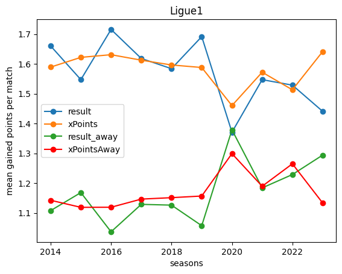

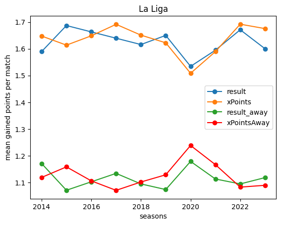

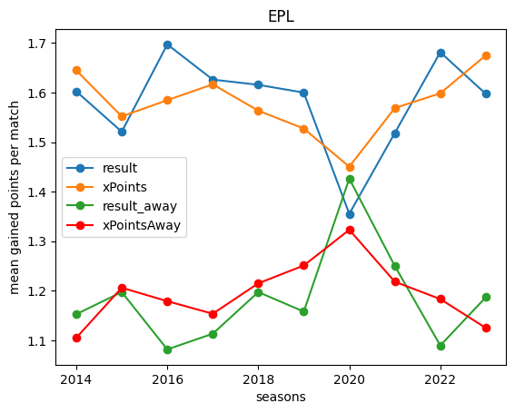

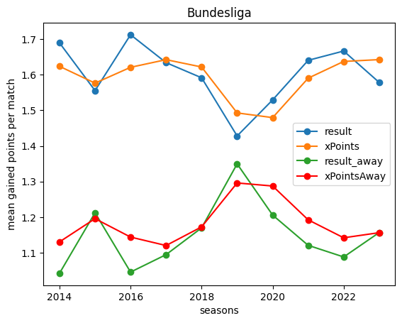

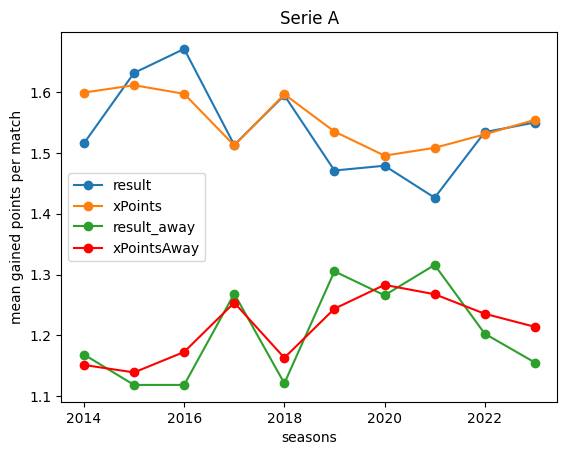

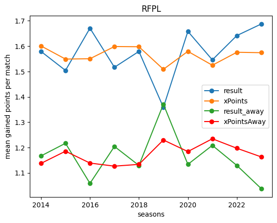

```python
for i, league in enumerate(leagues):
    league_data = df[df['ligue'] == league]  # Filter for league
    plt.plot(league_data['season'], league_data['avg_pts_h'], marker='o', label='result')
    plt.plot(league_data['season'], league_data['avg_xpts_h'], marker='o', label='xPoints')
    plt.plot(league_data['season'], league_data['avg_pts_a'], marker='o', label='result_away')
    plt.plot(league_data['season'], league_data['avg_xpts_a'], marker='o', label='xPointsAway', color='red')
    plt.xlabel('seasons')
    plt.ylabel('mean gained points per match')
    plt.title(league)
    plt.legend()
    plt.show()
```

### Statistical Analysis of Home Advantage

By performing **Wilcoxon Signed-Rank** tests and calculating **Cohen’s d effect** sizes, we aim to quantify the differences between home and away performances both before, during, and after the pandemic. This analysis investigates:

1. **Statistical Significance:** Using Wilcoxon p-values to determine whether differences in metrics such as points (pts), expected points (xPoints), and expected goals (xG) between home and away teams are significant.
2. **Effect Sizes:** Using Cohen’s d to measure the magnitude of these differences and assess the practical impact of home advantage.

```python
results_stat = pd.DataFrame()
```

#### Ligue 1

```python
dataframes = {
    # Ligue 1
    2014: df_ligue1_2014,
    2015: df_ligue1_2015,
    2016: df_ligue1_2016,
    2017: df_ligue1_2017,
    2018: df_ligue1_2018,
    2019: df_ligue1_2019,
    2020: df_ligue1_2020,
    2021: df_ligue1_2021,
    2022: df_ligue1_2022,
    2023: df_ligue1_2023,
}
```

```python
for season, df in dataframes.items():
    # Filter data for home and away games
    home_pts = df[df['h_a'] == 'h']['pts']
    away_pts = df[df['h_a'] == 'a']['pts']
    home_xpts = df[df['h_a'] == 'h']['xpts']
    away_xpts = df[df['h_a'] == 'a']['xpts']
    home_xg = df[df['h_a'] == 'h']['xG']
    away_xg = df[df['h_a'] == 'a']['xG']

    # Perform Wilcoxon Signed-Rank tests
    wilco_result = stats.wilcoxon(home_pts, away_pts, alternative='two-sided')
    wilco_xpts = stats.wilcoxon(home_xpts, away_xpts, alternative='two-sided')
    wilco_xg = stats.wilcoxon(home_xg, away_xg, alternative='two-sided')

    # Calculate Cohen's d for each metric
    cohend_result = (home_pts.mean() - away_pts.mean()) / np.sqrt((home_pts.std() ** 2 + away_pts.std() ** 2) / 2)
    cohend_xpts = (home_xpts.mean() - away_xpts.mean()) / np.sqrt((home_xpts.std() ** 2 + away_xpts.std() ** 2) / 2)
    cohend_xg = (home_xg.mean() - away_xg.mean()) / np.sqrt((home_xg.std() ** 2 + away_xg.std() ** 2) / 2)

    # Store results in a dictionary
    result = {
        "league": "Ligue_1",
        "season": season,
        "wilco-result": wilco_result.statistic,
        "wilco-result-pvalue": wilco_result.pvalue,
        "result-cohend": cohend_result,
        "wilco-xPoints": wilco_xpts.statistic,
        "wilco-xPoints-pvalue": wilco_xpts.pvalue,
        "xPoints-cohend": cohend_xpts,
        "wilco-xG": wilco_xg.statistic,
        "wilco-xG-pvalue": wilco_xg.pvalue,
        "xG-cohend": cohend_xg,
    }

    # Append the result to the results list
    results_stat = pd.concat([results_stat, pd.DataFrame([result])], ignore_index=True)
```

#### La Liga

```python
dataframes = {
    # La Liga
    2014: df_laliga_2014,
    2015: df_laliga_2015,
    2016: df_laliga_2016,
    2017: df_laliga_2017,
    2018: df_laliga_2018,
    2019: df_laliga_2019,
    2020: df_laliga_2020,
    2021: df_laliga_2021,
    2022: df_laliga_2022,
    2023: df_laliga_2023,
}
```

```python
for season, df in dataframes.items():
    # Filter data for home and away games
    home_pts = df[df['h_a'] == 'h']['pts']
    away_pts = df[df['h_a'] == 'a']['pts']
    home_xpts = df[df['h_a'] == 'h']['xpts']
    away_xpts = df[df['h_a'] == 'a']['xpts']
    home_xg = df[df['h_a'] == 'h']['xG']
    away_xg = df[df['h_a'] == 'a']['xG']

    # Perform Wilcoxon Signed-Rank tests
    wilco_result = stats.wilcoxon(home_pts, away_pts, alternative='two-sided')
    wilco_xpts = stats.wilcoxon(home_xpts, away_xpts, alternative='two-sided')
    wilco_xg = stats.wilcoxon(home_xg, away_xg, alternative='two-sided')

    # Calculate Cohen's d for each metric
    cohend_result = (home_pts.mean() - away_pts.mean()) / np.sqrt((home_pts.std() ** 2 + away_pts.std() ** 2) / 2)
    cohend_xpts = (home_xpts.mean() - away_xpts.mean()) / np.sqrt((home_xpts.std() ** 2 + away_xpts.std() ** 2) / 2)
    cohend_xg = (home_xg.mean() - away_xg.mean()) / np.sqrt((home_xg.std() ** 2 + away_xg.std() ** 2) / 2)

    # Store results in a dictionary
    result = {
        "league": "La_Liga",
        "season": season,
        "wilco-result": wilco_result.statistic,
        "wilco-result-pvalue": wilco_result.pvalue,
        "result-cohend": cohend_result,
        "wilco-xPoints": wilco_xpts.statistic,
        "wilco-xPoints-pvalue": wilco_xpts.pvalue,
        "xPoints-cohend": cohend_xpts,
        "wilco-xG": wilco_xg.statistic,
        "wilco-xG-pvalue": wilco_xg.pvalue,
        "xG-cohend": cohend_xg,
    }

    # Append the result to the results list
    results_stat = pd.concat([results_stat, pd.DataFrame([result])], ignore_index=True)
```

#### EPL

```python
dataframes = {
    # EPL
    2014: df_epl_2014,
    2015: df_epl_2015,
    2016: df_epl_2016,
    2017: df_epl_2017,
    2018: df_epl_2018,
    2019: df_epl_2019,
    2020: df_epl_2020,
    2021: df_epl_2021,
    2022: df_epl_2022,
    2023: df_epl_2023,
}
```

```python
for season, df in dataframes.items():
    # Filter data for home and away games
    home_pts = df[df['h_a'] == 'h']['pts']
    away_pts = df[df['h_a'] == 'a']['pts']
    home_xpts = df[df['h_a'] == 'h']['xpts']
    away_xpts = df[df['h_a'] == 'a']['xpts']
    home_xg = df[df['h_a'] == 'h']['xG']
    away_xg = df[df['h_a'] == 'a']['xG']

    # Perform Wilcoxon Signed-Rank tests
    wilco_result = stats.wilcoxon(home_pts, away_pts, alternative='two-sided')
    wilco_xpts = stats.wilcoxon(home_xpts, away_xpts, alternative='two-sided')
    wilco_xg = stats.wilcoxon(home_xg, away_xg, alternative='two-sided')

    # Calculate Cohen's d for each metric
    cohend_result = (home_pts.mean() - away_pts.mean()) / np.sqrt((home_pts.std() ** 2 + away_pts.std() ** 2) / 2)
    cohend_xpts = (home_xpts.mean() - away_xpts.mean()) / np.sqrt((home_xpts.std() ** 2 + away_xpts.std() ** 2) / 2)
    cohend_xg = (home_xg.mean() - away_xg.mean()) / np.sqrt((home_xg.std() ** 2 + away_xg.std() ** 2) / 2)

    # Store results in a dictionary
    result = {
        "league": "EPL",
        "season": season,
        "wilco-result": wilco_result.statistic,
        "wilco-result-pvalue": wilco_result.pvalue,
        "result-cohend": cohend_result,
        "wilco-xPoints": wilco_xpts.statistic,
        "wilco-xPoints-pvalue": wilco_xpts.pvalue,
        "xPoints-cohend": cohend_xpts,
        "wilco-xG": wilco_xg.statistic,
        "wilco-xG-pvalue": wilco_xg.pvalue,
        "xG-cohend": cohend_xg,
    }

    # Append the result to the results list
    results_stat = pd.concat([results_stat, pd.DataFrame([result])], ignore_index=True)
```

#### Bundesliga

```python
dataframes = {
    # Bundesliga
    2014: df_bundesliga_2014,
    2015: df_bundesliga_2015,
    2016: df_bundesliga_2016,
    2017: df_bundesliga_2017,
    2018: df_bundesliga_2018,
    2019: df_bundesliga_2019,
    2020: df_bundesliga_2020,
    2021: df_bundesliga_2021,
    2022: df_bundesliga_2022,
    2023: df_bundesliga_2023,
}
```

```python
for season, df in dataframes.items():
    # Filter data for home and away games
    home_pts = df[df['h_a'] == 'h']['pts']
    away_pts = df[df['h_a'] == 'a']['pts']
    home_xpts = df[df['h_a'] == 'h']['xpts']
    away_xpts = df[df['h_a'] == 'a']['xpts']
    home_xg = df[df['h_a'] == 'h']['xG']
    away_xg = df[df['h_a'] == 'a']['xG']

    # Perform Wilcoxon Signed-Rank tests
    wilco_result = stats.wilcoxon(home_pts, away_pts, alternative='two-sided')
    wilco_xpts = stats.wilcoxon(home_xpts, away_xpts, alternative='two-sided')
    wilco_xg = stats.wilcoxon(home_xg, away_xg, alternative='two-sided')

    # Calculate Cohen's d for each metric
    cohend_result = (home_pts.mean() - away_pts.mean()) / np.sqrt((home_pts.std() ** 2 + away_pts.std() ** 2) / 2)
    cohend_xpts = (home_xpts.mean() - away_xpts.mean()) / np.sqrt((home_xpts.std() ** 2 + away_xpts.std() ** 2) / 2)
    cohend_xg = (home_xg.mean() - away_xg.mean()) / np.sqrt((home_xg.std() ** 2 + away_xg.std() ** 2) / 2)

    # Store results in a dictionary
    result = {
        "league": "Bundesliga",
        "season": season,
        "wilco-result": wilco_result.statistic,
        "wilco-result-pvalue": wilco_result.pvalue,
        "result-cohend": cohend_result,
        "wilco-xPoints": wilco_xpts.statistic,
        "wilco-xPoints-pvalue": wilco_xpts.pvalue,
        "xPoints-cohend": cohend_xpts,
        "wilco-xG": wilco_xg.statistic,
        "wilco-xG-pvalue": wilco_xg.pvalue,
        "xG-cohend": cohend_xg,
    }

    # Append the result to the results list
    results_stat = pd.concat([results_stat, pd.DataFrame([result])], ignore_index=True)
```

#### Serie A

```python
dataframes = {
    # Serie A
    2014: df_seriea_2014,
    2015: df_seriea_2015,
    2016: df_seriea_2016,
    2017: df_seriea_2017,
    2018: df_seriea_2018,
    2019: df_seriea_2019,
    2020: df_seriea_2020,
    2021: df_seriea_2021,
    2022: df_seriea_2022,
    2023: df_seriea_2023,
}
```

```python
for season, df in dataframes.items():
    # Filter data for home and away games
    home_pts = df[df['h_a'] == 'h']['pts']
    away_pts = df[df['h_a'] == 'a']['pts']
    home_xpts = df[df['h_a'] == 'h']['xpts']
    away_xpts = df[df['h_a'] == 'a']['xpts']
    home_xg = df[df['h_a'] == 'h']['xG']
    away_xg = df[df['h_a'] == 'a']['xG']

    # Perform Wilcoxon Signed-Rank tests
    wilco_result = stats.wilcoxon(home_pts, away_pts, alternative='two-sided')
    wilco_xpts = stats.wilcoxon(home_xpts, away_xpts, alternative='two-sided')
    wilco_xg = stats.wilcoxon(home_xg, away_xg, alternative='two-sided')

    # Calculate Cohen's d for each metric
    cohend_result = (home_pts.mean() - away_pts.mean()) / np.sqrt((home_pts.std() ** 2 + away_pts.std() ** 2) / 2)
    cohend_xpts = (home_xpts.mean() - away_xpts.mean()) / np.sqrt((home_xpts.std() ** 2 + away_xpts.std() ** 2) / 2)
    cohend_xg = (home_xg.mean() - away_xg.mean()) / np.sqrt((home_xg.std() ** 2 + away_xg.std() ** 2) / 2)

    # Store results in a dictionary
    result = {
        "league": "Serie_A",
        "season": season,
        "wilco-result": wilco_result.statistic,
        "wilco-result-pvalue": wilco_result.pvalue,
        "result-cohend": cohend_result,
        "wilco-xPoints": wilco_xpts.statistic,
        "wilco-xPoints-pvalue": wilco_xpts.pvalue,
        "xPoints-cohend": cohend_xpts,
        "wilco-xG": wilco_xg.statistic,
        "wilco-xG-pvalue": wilco_xg.pvalue,
        "xG-cohend": cohend_xg,
    }

    # Append the result to the results list
    results_stat = pd.concat([results_stat, pd.DataFrame([result])], ignore_index=True)
```

#### RFPL

```python
dataframes = {
    # RFPL
    2014: df_rfpl_2014,
    2015: df_rfpl_2015,
    2016: df_rfpl_2016,
    2017: df_rfpl_2017,
    2018: df_rfpl_2018,
    2019: df_rfpl_2019,
    2020: df_rfpl_2020,
    2021: df_rfpl_2021,
    2022: df_rfpl_2022,
    2023: df_rfpl_2023
}
```

```python
for season, df in dataframes.items():
    # Filter data for home and away games
    home_pts = df[df['h_a'] == 'h']['pts']
    away_pts = df[df['h_a'] == 'a']['pts']
    home_xpts = df[df['h_a'] == 'h']['xpts']
    away_xpts = df[df['h_a'] == 'a']['xpts']
    home_xg = df[df['h_a'] == 'h']['xG']
    away_xg = df[df['h_a'] == 'a']['xG']

    # Perform Wilcoxon Signed-Rank tests
    wilco_result = stats.wilcoxon(home_pts, away_pts, alternative='two-sided')
    wilco_xpts = stats.wilcoxon(home_xpts, away_xpts, alternative='two-sided')
    wilco_xg = stats.wilcoxon(home_xg, away_xg, alternative='two-sided')

    # Calculate Cohen's d for each metric
    cohend_result = (home_pts.mean() - away_pts.mean()) / np.sqrt((home_pts.std() ** 2 + away_pts.std() ** 2) / 2)
    cohend_xpts = (home_xpts.mean() - away_xpts.mean()) / np.sqrt((home_xpts.std() ** 2 + away_xpts.std() ** 2) / 2)
    cohend_xg = (home_xg.mean() - away_xg.mean()) / np.sqrt((home_xg.std() ** 2 + away_xg.std() ** 2) / 2)

    # Store results in a dictionary
    result = {
        "league": "RFPL",
        "season": season,
        "wilco-result": wilco_result.statistic,
        "wilco-result-pvalue": wilco_result.pvalue,
        "result-cohend": cohend_result,
        "wilco-xPoints": wilco_xpts.statistic,
        "wilco-xPoints-pvalue": wilco_xpts.pvalue,
        "xPoints-cohend": cohend_xpts,
        "wilco-xG": wilco_xg.statistic,
        "wilco-xG-pvalue": wilco_xg.pvalue,
        "xG-cohend": cohend_xg,
    }

    # Append the result to the results list
    results_stat = pd.concat([results_stat, pd.DataFrame([result])], ignore_index=True)
```

```python
def highlight_pvalues(val):
    try:
        if pd.notna(val) and float(val) >= 0.05:
            return 'color: red;'  # Highlight significant p-values in red
    except ValueError:
        pass
    return ''

# Create a function to style effect sizes (Cohen's d)
def highlight_effect_size(val):
    try:
        val = float(val)
        if val < 0.20:  # Small effect size
            return 'background-color: yellow;'
    except ValueError:
        pass
    return ''
```

```python
styled_results_stat = results_stat.style.applymap(highlight_pvalues, subset=[
    'wilco-result-pvalue', 'wilco-xPoints-pvalue', 'wilco-xG-pvalue'
]).applymap(highlight_effect_size, subset=[
    'result-cohend', 'xPoints-cohend', 'xG-cohend'
])
```

```python
styled_results_stat
```

|  | league | season | wilco-result | wilco-result-pvalue | result-cohend | wilco-xPoints | wilco-xPoints-pvalue | xPoints-cohend | wilco-xG | wilco-xG-pvalue | xG-cohend |
| --- | --- | --- | --- | --- | --- | --- | --- | --- | --- | --- | --- |
| 0 | Ligue_1 | 2014 | 10430.000000 | 0.000000 | 0.423654 | 19144.000000 | 0.000000 | 0.592618 | 23087.000000 | 0.000000 | 0.428402 |
| 1 | Ligue_1 | 2015 | 8765.000000 | 0.000009 | 0.296835 | 16363.500000 | 0.000000 | 0.665501 | 21230.000000 | 0.000000 | 0.484468 |
| 2 | Ligue_1 | 2016 | 8413.000000 | 0.000000 | 0.531954 | 17052.500000 | 0.000000 | 0.676671 | 21441.000000 | 0.000000 | 0.479961 |
| 3 | Ligue_1 | 2017 | 7391.000000 | 0.000000 | 0.378394 | 18828.500000 | 0.000000 | 0.576631 | 22750.000000 | 0.000000 | 0.439724 |
| 4 | Ligue_1 | 2018 | 7785.000000 | 0.000000 | 0.361783 | 19937.000000 | 0.000000 | 0.578288 | 21101.000000 | 0.000000 | 0.444494 |
| 5 | Ligue_1 | 2019 | 3815.500000 | 0.000000 | 0.495734 | 10871.000000 | 0.000000 | 0.558692 | 12409.000000 | 0.000000 | 0.440770 |
| 6 | Ligue_1 | 2020 | 15212.500000 | 0.927026 | -0.005987 | 30974.000000 | 0.014820 | 0.191954 | 31832.000000 | 0.041719 | 0.190976 |
| 7 | Ligue_1 | 2021 | 11016.500000 | 0.000073 | 0.281310 | 21537.500000 | 0.000000 | 0.474469 | 24693.000000 | 0.000000 | 0.358162 |
| 8 | Ligue_1 | 2022 | 11562.000000 | 0.002543 | 0.227875 | 26669.000000 | 0.000009 | 0.293654 | 29106.000000 | 0.000938 | 0.249767 |
| 9 | Ligue_1 | 2023 | 8840.000000 | 0.166256 | 0.112682 | 11729.000000 | 0.000000 | 0.658474 | 13482.000000 | 0.000000 | 0.503303 |
| 10 | La_Liga | 2014 | 8462.500000 | 0.000007 | 0.319278 | 16927.000000 | 0.000000 | 0.620607 | 20112.000000 | 0.000000 | 0.446100 |
| 11 | La_Liga | 2015 | 8465.500000 | 0.000000 | 0.477844 | 18921.500000 | 0.000000 | 0.541456 | 21406.000000 | 0.000000 | 0.435300 |
| 12 | La_Liga | 2016 | 8089.500000 | 0.000000 | 0.430693 | 16642.500000 | 0.000000 | 0.673844 | 20573.000000 | 0.000000 | 0.475527 |
| 13 | La_Liga | 2017 | 9190.000000 | 0.000000 | 0.384669 | 14296.000000 | 0.000000 | 0.809467 | 18850.000000 | 0.000000 | 0.581820 |
| 14 | La_Liga | 2018 | 9176.000000 | 0.000000 | 0.413690 | 15717.000000 | 0.000000 | 0.752073 | 21240.000000 | 0.000000 | 0.495956 |
| 15 | La_Liga | 2019 | 8792.500000 | 0.000000 | 0.455695 | 18364.500000 | 0.000000 | 0.639135 | 22308.000000 | 0.000000 | 0.490250 |
| 16 | La_Liga | 2020 | 10040.000000 | 0.000198 | 0.278394 | 25536.000000 | 0.000001 | 0.327076 | 28265.000000 | 0.000215 | 0.258653 |
| 17 | La_Liga | 2021 | 10121.000000 | 0.000001 | 0.381837 | 20697.000000 | 0.000000 | 0.528827 | 24073.000000 | 0.000000 | 0.383139 |
| 18 | La_Liga | 2022 | 8491.000000 | 0.000000 | 0.443415 | 14708.000000 | 0.000000 | 0.757926 | 18805.000000 | 0.000000 | 0.579781 |
| 19 | La_Liga | 2023 | 10420.500000 | 0.000002 | 0.379151 | 15323.000000 | 0.000000 | 0.766136 | 20396.000000 | 0.000000 | 0.572058 |
| 20 | EPL | 2014 | 9226.500000 | 0.000001 | 0.345195 | 15262.500000 | 0.000000 | 0.740617 | 19612.000000 | 0.000000 | 0.556300 |
| 21 | EPL | 2015 | 10941.500000 | 0.000467 | 0.252358 | 23636.000000 | 0.000000 | 0.437532 | 26454.000000 | 0.000005 | 0.345494 |
| 22 | EPL | 2016 | 6807.000000 | 0.000000 | 0.471545 | 21308.000000 | 0.000000 | 0.490595 | 23524.000000 | 0.000000 | 0.412790 |
| 23 | EPL | 2017 | 8050.000000 | 0.000000 | 0.399434 | 19440.000000 | 0.000000 | 0.545943 | 21727.000000 | 0.000000 | 0.451265 |
| 24 | EPL | 2018 | 8692.000000 | 0.000019 | 0.309421 | 23434.000000 | 0.000000 | 0.409252 | 24421.000000 | 0.000000 | 0.383554 |
| 25 | EPL | 2019 | 9000.000000 | 0.000002 | 0.338407 | 26100.500000 | 0.000002 | 0.323580 | 27508.500000 | 0.000050 | 0.247227 |
| 26 | EPL | 2020 | 12800.500000 | 0.352127 | -0.052890 | 31145.000000 | 0.018426 | 0.147293 | 32367.000000 | 0.074000 | 0.151084 |
| 27 | EPL | 2021 | 9917.000000 | 0.003687 | 0.202327 | 22720.000000 | 0.000000 | 0.396080 | 24984.000000 | 0.000000 | 0.313509 |
| 28 | EPL | 2022 | 7841.000000 | 0.000000 | 0.454684 | 21164.500000 | 0.000000 | 0.497709 | 23217.000000 | 0.000000 | 0.427556 |
| 29 | EPL | 2023 | 8888.000000 | 0.000032 | 0.308631 | 16777.000000 | 0.000000 | 0.655238 | 21668.000000 | 0.000000 | 0.478267 |
| 30 | Bundesliga | 2014 | 5550.000000 | 0.000000 | 0.512082 | 11660.000000 | 0.000000 | 0.656084 | 13479.000000 | 0.000000 | 0.494055 |
| 31 | Bundesliga | 2015 | 6916.500000 | 0.000981 | 0.259479 | 14055.500000 | 0.000000 | 0.458798 | 15093.000000 | 0.000000 | 0.400803 |
| 32 | Bundesliga | 2016 | 5251.000000 | 0.000000 | 0.519632 | 12081.000000 | 0.000000 | 0.597053 | 14459.000000 | 0.000000 | 0.469160 |
| 33 | Bundesliga | 2017 | 5128.000000 | 0.000000 | 0.423421 | 11373.500000 | 0.000000 | 0.668095 | 13729.000000 | 0.000000 | 0.510562 |
| 34 | Bundesliga | 2018 | 5290.500000 | 0.000035 | 0.321458 | 13264.500000 | 0.000000 | 0.524064 | 15887.000000 | 0.000001 | 0.400589 |
| 35 | Bundesliga | 2019 | 9463.500000 | 0.466960 | 0.058499 | 18458.000000 | 0.001172 | 0.228196 | 19437.000000 | 0.008959 | 0.166438 |
| 36 | Bundesliga | 2020 | 7010.000000 | 0.002147 | 0.249430 | 18533.000000 | 0.001388 | 0.234553 | 19419.000000 | 0.008659 | 0.221322 |
| 37 | Bundesliga | 2021 | 5691.500000 | 0.000001 | 0.398909 | 13433.500000 | 0.000000 | 0.479701 | 15453.000000 | 0.000000 | 0.332823 |
| 38 | Bundesliga | 2022 | 5644.000000 | 0.000000 | 0.448062 | 12475.000000 | 0.000000 | 0.604823 | 14635.000000 | 0.000000 | 0.460537 |
| 39 | Bundesliga | 2023 | 6003.000000 | 0.000027 | 0.326799 | 12630.500000 | 0.000000 | 0.570377 | 14191.000000 | 0.000000 | 0.460721 |
| 40 | Serie_A | 2014 | 9685.000000 | 0.000102 | 0.277456 | 18167.500000 | 0.000000 | 0.590786 | 22544.000000 | 0.000000 | 0.418651 |
| 41 | Serie_A | 2015 | 8707.500000 | 0.000000 | 0.396744 | 17626.000000 | 0.000000 | 0.608929 | 23005.000000 | 0.000000 | 0.450818 |
| 42 | Serie_A | 2016 | 8270.000000 | 0.000000 | 0.418215 | 20470.500000 | 0.000000 | 0.516640 | 23512.000000 | 0.000000 | 0.408999 |
| 43 | Serie_A | 2017 | 9407.000000 | 0.010724 | 0.182875 | 27575.500000 | 0.000057 | 0.302619 | 28111.000000 | 0.000161 | 0.287408 |
| 44 | Serie_A | 2018 | 8920.500000 | 0.000000 | 0.373370 | 20253.000000 | 0.000000 | 0.565626 | 23160.000000 | 0.000000 | 0.416131 |
| 45 | Serie_A | 2019 | 11376.500000 | 0.087206 | 0.123988 | 24982.500000 | 0.000000 | 0.355731 | 27057.000000 | 0.000020 | 0.298745 |
| 46 | Serie_A | 2020 | 11624.000000 | 0.029121 | 0.162705 | 28066.000000 | 0.000148 | 0.248607 | 30028.000000 | 0.003999 | 0.185808 |
| 47 | Serie_A | 2021 | 13746.000000 | 0.227183 | 0.084299 | 26780.000000 | 0.000011 | 0.285681 | 29091.000000 | 0.000914 | 0.226252 |
| 48 | Serie_A | 2022 | 9643.000000 | 0.000258 | 0.255567 | 25295.000000 | 0.000000 | 0.356687 | 28207.000000 | 0.000193 | 0.263408 |
| 49 | Serie_A | 2023 | 11136.000000 | 0.000008 | 0.311670 | 24047.500000 | 0.000000 | 0.413012 | 26651.000000 | 0.000008 | 0.345728 |
| 50 | RFPL | 2014 | 4462.500000 | 0.001357 | 0.317306 | 7605.000000 | 0.000000 | 0.589580 | 8222.000000 | 0.000000 | 0.481784 |
| 51 | RFPL | 2015 | 4481.500000 | 0.009209 | 0.223249 | 8854.000000 | 0.000000 | 0.470797 | 9981.000000 | 0.000032 | 0.351776 |
| 52 | RFPL | 2016 | 3965.500000 | 0.000000 | 0.483788 | 7982.000000 | 0.000000 | 0.570486 | 9834.000000 | 0.000017 | 0.380330 |
| 53 | RFPL | 2017 | 3815.000000 | 0.004492 | 0.242938 | 6998.000000 | 0.000000 | 0.629140 | 8556.000000 | 0.000000 | 0.456407 |
| 54 | RFPL | 2018 | 4277.000000 | 0.000053 | 0.355595 | 7358.000000 | 0.000000 | 0.616734 | 8482.000000 | 0.000000 | 0.457948 |
| 55 | RFPL | 2019 | 5690.500000 | 0.928625 | -0.009595 | 9745.000000 | 0.000012 | 0.388441 | 10522.000000 | 0.000255 | 0.308154 |
| 56 | RFPL | 2020 | 3350.000000 | 0.000016 | 0.395631 | 8678.000000 | 0.000000 | 0.462553 | 9857.000000 | 0.000028 | 0.372773 |
| 57 | RFPL | 2021 | 5257.500000 | 0.008637 | 0.257198 | 9938.000000 | 0.000027 | 0.350780 | 10957.000000 | 0.001140 | 0.280228 |
| 58 | RFPL | 2022 | 3869.500000 | 0.000076 | 0.390773 | 8966.000000 | 0.000000 | 0.448572 | 9627.000000 | 0.000007 | 0.406113 |
| 59 | RFPL | 2023 | 3215.500000 | 0.000000 | 0.516775 | 7864.000000 | 0.000000 | 0.584829 | 9673.000000 | 0.000009 | 0.397880 |

The combination of Wilcoxon p-values and Cohen’s d effect sizes provides robust evidence of these shifts, emphasizing the role of external factors like crowd support in shaping football outcomes.

## Champions League Data as a Variability Factor

For a second variability factor, we decided to pull Champions League matches data from *stathead.com*. This dataset covers **pre-COVID seasons (2017–2019)**, the **COVID-impacted season (2019–2020)** with no fans, and **post-COVID seasons (2021–2023)** with varying levels of recovery in crowd attendance and team dynamics.

Analyzing the 2017–2023 Champions League seasons introduces a valuable variability factor by leveraging the unique features of this international competition. It allows us to:

1. Test the robustness of home/away dynamics across a wide range of teams, venues, and contexts.
2. Evaluate the impact of global events (like COVID) and high-pressure match contexts on the original findings.
3. Strengthen the conclusions of the replication by demonstrating whether the results generalize beyond domestic leagues to elite international football.

This dataset provides a rich testing ground for exploring variability while maintaining relevance to the original study.

### Importing and Cleaning Champions Lague Data

```python
df = pd.read_csv("database_ucl_stathead.csv")
df
```

|  | Rk | Team | Date | xG | h_a | Opp | Comp | Round | TieRslt | Result | ... | A-xAG | npxG/Sh | Sh | G/Sh | G/SoT | SoT | SoT% | Dist | FK | Match Report |
| --- | --- | --- | --- | --- | --- | --- | --- | --- | --- | --- | --- | --- | --- | --- | --- | --- | --- | --- | --- | --- | --- |
| 0 | 1 | de Dortmund | 2024-06-01 | 2.1 | NaN | es Real Madrid | Champions League | Final | NaN | L 0-2 | ... | -1.2 | 0.17 | 13 | 0.00 | 0.00 | 3 | 23.1 | 16.2 | 0 | Match Report |
| 1 | 2 | es Real Madrid | 2024-06-01 | 1.1 | @ | de Dortmund | Champions League | Final | NaN | W 2-0 | ... | 1.1 | 0.09 | 13 | 0.15 | 0.33 | 6 | 46.2 | 17.1 | 2 | Match Report |
| 2 | 3 | de Bayern Munich | 2024-05-08 | 0.4 | @ | es Real Madrid | Champions League | Semi-finals Leg 2 | L 3-4 | L 1-2 | ... | 0.8 | 0.04 | 8 | 0.13 | 0.20 | 5 | 62.5 | 17.4 | 0 | Match Report |
| 3 | 4 | es Real Madrid | 2024-05-08 | 2.8 | NaN | de Bayern Munich | Champions League | Semi-finals Leg 2 | W 4-3 | W 2-1 | ... | -0.7 | 0.16 | 19 | 0.11 | 0.29 | 7 | 36.8 | 17.6 | 1 | Match Report |
| 4 | 5 | fr Paris S-G | 2024-05-07 | 3.0 | NaN | de Dortmund | Champions League | Semi-finals Leg 2 | L 0-2 | L 0-1 | ... | -2.4 | 0.11 | 30 | 0.00 | 0.00 | 5 | 16.7 | 17.5 | 1 | Match Report |
| ... | ... | ... | ... | ... | ... | ... | ... | ... | ... | ... | ... | ... | ... | ... | ... | ... | ... | ... | ... | ... | ... |
| 1733 | 1734 | ch Basel | 2017-09-12 | 0.6 | @ | eng Manchester Utd | Champions League | Group | NaN | L 0-3 | ... | -0.5 | 0.07 | 8 | 0.00 | 0.00 | 2 | 25.0 | 19.5 | 0 | Match Report |
| 1734 | 1735 | es Atlético Madrid | 2017-09-12 | 2.4 | @ | it Roma | Champions League | Group | NaN | D 0-0 | ... | -1.8 | 0.13 | 20 | 0.00 | 0.00 | 9 | 45.0 | 20.3 | 1 | Match Report |
| 1735 | 1736 | it Juventus | 2017-09-12 | 0.7 | @ | es Barcelona | Champions League | Group | NaN | L 0-3 | ... | -0.5 | 0.05 | 13 | 0.00 | 0.00 | 6 | 46.2 | 20.0 | 0 | Match Report |
| 1736 | 1737 | fr Paris S-G | 2017-09-12 | 2.5 | @ | sct Celtic | Champions League | Group | NaN | W 5-0 | ... | 1.2 | 0.20 | 9 | 0.33 | 0.60 | 5 | 55.6 | 16.9 | 0 | Match Report |
| 1737 | 1738 | ru CSKA Moscow | 2017-09-12 | 1.6 | @ | pt Benfica | Champions League | Group | NaN | W 2-1 | ... | -0.5 | 0.08 | 13 | 0.08 | 0.17 | 6 | 46.2 | 19.1 | 0 | Match Report |

1738 rows × 36 columns

```python
count_at = df['h_a'].value_counts().get('@', 0)

# Display the result
print(f"The number of occurrences of '@' in the 'h_a' column is: {count_at}")
```

```
The number of occurrences of '@' in the 'h_a' column is: 855
```

```python
# Function to extract the season based on the date string
def assign_season_from_string(date_str):
    if pd.isna(date_str):
        return None  # Handle missing dates explicitly
    # Extract year and month from the date string
    year = int(date_str[:4])  # First 4 characters represent the year
    month = int(date_str[5:7])  # Characters 5-7 represent the month
    if month >= 9:  # Matches between September and December belong to the current year
        return year
    elif month <= 8:  # Matches between January and August belong to the previous year
        return year - 1
    else:
        return None  # This should not occur
```

```python
# Function to clean and transform the DataFrame
def new_dataframe(df):
    # Rename the 'Team' column to 'team_name'
    df.rename(columns={"Team": "team_name"}, inplace=True)
    df.rename(columns={"Round": "match_round"}, inplace=True)

    # Update 'h_a' column logic
    df['h_a'] = df['h_a'].apply(lambda x: 'h' if pd.isna(x) else 'a')

    # Extract the season from the 'Date' column (kept as string)
    df['season'] = df['Date'].apply(assign_season_from_string)
    df = df[df['season'].notna()]  # Filter out rows with missing seasons
    df['season'] = df['season'].astype(int)  # Ensure 'season' is an integer

    # Keep only the necessary columns
    columns_to_keep = ['team_name', 'season', 'h_a', 'xG', 'match_round', 'GF', 'GA', 'GD']
    df = df[columns_to_keep]

    return df
```

```python
df_ucl = new_dataframe(df)
df_ucl.head()
```

|  | team_name | season | h_a | xG | match_round | GF | GA | GD |
| --- | --- | --- | --- | --- | --- | --- | --- | --- |
| 0 | de Dortmund | 2023 | h | 2.1 | Final | 0 | 2 | -2 |
| 1 | es Real Madrid | 2023 | a | 1.1 | Final | 2 | 0 | 2 |
| 2 | de Bayern Munich | 2023 | a | 0.4 | Semi-finals Leg 2 | 1 | 2 | -1 |
| 3 | es Real Madrid | 2023 | h | 2.8 | Semi-finals Leg 2 | 2 | 1 | 1 |
| 4 | fr Paris S-G | 2023 | h | 3.0 | Semi-finals Leg 2 | 0 | 1 | -1 |

### Table with bar charts to visualize and investigate a possible effect of COVID on home advantage

```python
# Function to calculate grouped results
def calculate_seasonal_sums(df):
    # Group by season and calculate the sums
    grouped = df.groupby('season').apply(lambda group: pd.Series({
        'sum_points_away': group.loc[group['h_a'] == 'a', 'GF'].sum(),  # Sum of GF where h_a == 'a'
        'sum_points_home': group.loc[group['h_a'] == 'h', 'GF'].sum(),  # Sum of GF where h_a == 'h'
        'sum_xG_away': group.loc[group['h_a'] == 'a', 'xG'].sum(),      # Sum of xG where h_a == 'a'
        'sum_xG_home': group.loc[group['h_a'] == 'h', 'xG'].sum(),      # Sum of xG where h_a == 'h'
        'avg_points_away':  group.loc[group['h_a'] == 'a', 'GF'].mean(),
        'avg_points_home':  group.loc[group['h_a'] == 'h', 'GF'].mean(),
        'avg_xG_away': group.loc[group['h_a'] == 'a', 'xG'].mean(),      # Sum of xG where h_a == 'a'
        'avg_xG_home': group.loc[group['h_a'] == 'h', 'xG'].mean()
    })).reset_index()

    return grouped
```

```python
results = calculate_seasonal_sums(df_ucl)
```

```python
diff_results = pd.DataFrame({
    "LEAGUE": 'Champions League',
    "YEAR": results["season"],      # Keep the year column
    "DIFF_POINTS_HOMEAWAY": (results["sum_points_home"] - results["sum_points_away"]).round(0).astype(int),  # Calculate points difference
})
```

```python
styled_df = diff_results.style.bar(
    subset=["DIFF_POINTS_HOMEAWAY"],
    color=['lightcoral', 'mediumseagreen'],
    align='zero'  # Aligns negative bars to the left
)
styled_df
```

|  | LEAGUE | YEAR | DIFF_POINTS_HOMEAWAY |
| --- | --- | --- | --- |
| 0 | Champions League | 2017 | 39 |
| 1 | Champions League | 2018 | 58 |
| 2 | Champions League | 2019 | -2 |
| 3 | Champions League | 2020 | -8 |
| 4 | Champions League | 2021 | 17 |
| 5 | Champions League | 2022 | 35 |
| 6 | Champions League | 2023 | 56 |

We can see that even though the tournament features top teams from across Europe with varying tactical styles, squad depth, and historical dominance and different pressures and higher stakes than the national football competitions, we can still see that home advantage diminished significantly during the COVID season (between 2019 and 2020). We can put forward the hypothesis that the reason for this is the absence of crowds. Home advantage is often considered more pronounced in international tournaments due to long-distance travel, unfamiliar environments, and crowd hostility.

```python
diff_results = pd.DataFrame({
    "LEAGUE": 'Champions League',
    "YEAR": results["season"],      # Keep the year column
    "DIFF_XG_HOMEAWAY": (results["sum_xG_home"] - results["sum_xG_away"]).round(0).astype(int),  # Calculate points difference
})
```

```python
styled_df = diff_results.style.bar(
    subset=["DIFF_XG_HOMEAWAY"],
    color=['lightcoral', 'mediumseagreen'],
    align='zero'  # Aligns negative bars to the left
)
styled_df
```

|  | LEAGUE | YEAR | DIFF_XG_HOMEAWAY |
| --- | --- | --- | --- |
| 0 | Champions League | 2017 | 36 |
| 1 | Champions League | 2018 | 49 |
| 2 | Champions League | 2019 | 14 |
| 3 | Champions League | 2020 | 4 |
| 4 | Champions League | 2021 | 11 |
| 5 | Champions League | 2022 | 32 |
| 6 | Champions League | 2023 | 46 |

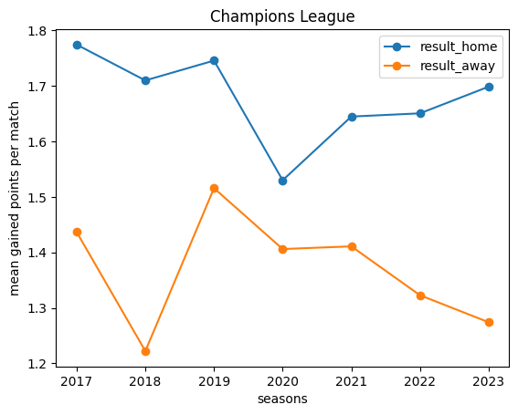

```python
plt.plot(results['season'], results['avg_points_home'], marker='o', label='result_home')
plt.plot(results['season'], results['avg_points_away'], marker='o', label='result_away')
plt.xlabel('seasons')
plt.ylabel('mean gained points per match')
plt.title('Champions League')
plt.legend()
plt.show()
```

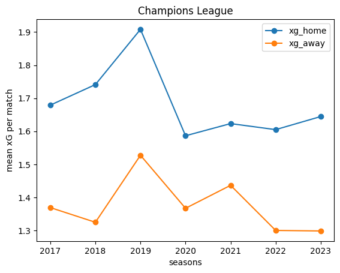

```python
plt.plot(results['season'], results['avg_xG_home'], marker='o', label='xg_home')
plt.plot(results['season'], results['avg_xG_away'], marker='o', label='xg_away')
plt.xlabel('seasons')
plt.ylabel('mean xG per match')
plt.title('Champions League')
plt.legend()
plt.show()
```